# Estudo dos crimes cometidos em Houston, Texas e previsão das forças de segurança necessárias

Rui Andrade, Iúri Pena, André Diegues

31 de Dezembro de 2016

## Apresentação do Dataset

Recebemos, numa spreadsheet Excel, uma lista de observações de crimes em Houston, Texas, entre 1915 e 2014. O dataset contém, para cada observação, a data e hora de ocorrência do crime, o tipo de crime, a região onde o crime ocorreu (police beat), o local (restaurante, biblioteca, …), os números de porta na rua onde o crime ocorreu, o nome da rua, o tipo de rua e sufixo (norte, sul, este, oeste, utilizado quando as ruas são muito grandes) e o número de vezes que a ocorrência se deu.

## Importação e pré-processamento dos dados

No que concerne ao tratamento de dados, a abordagem do nosso grupo foi bastante simples. Começámos por importar o dataset com a função *read.xls* do package *gdata*, indicando a existência de headers e quais as strings que representam dados desconhecidos:

```r
crimes <- read.xls("crime.xls", header=TRUE, na.strings=c("", "UNK", "-"))
```

Em seguida, eliminámos todas as observações anteriores a 01/01/2014, uma vez que a vasta maioria dos dados se centra em observações posteriores a essa data e as anteriores são demasiado antigas para utilizar de forma fiável na análise exploratória de dados e construção de modelos de previsão.

```r
crimes <- crimes[ymd(crimes$Date) >= ymd("2014-01-01"),]
```

Uma vez eliminadas estas entradas, procedemos ao tratamento dos dados que vão interessar para poder obter informações sobre o tema em questão. Conforme descrito no enunciado, cada dia pode ser dividido em três períodos: manhã (08:00 até 12:00), tarde (12:00 até 19:00) e noite (todas as horas restantes), pelo que inicialmente criámos uma coluna para reflectir isso mesmo. Isto viria a ser importante para a construção de gráficos que nos permitissem perceber, por exemplo, qual a altura do dia em que mais crimes acontecem. Foi, também, por este motivo que dividimos as datas de cada ocorrência em dia, mês, ano e dia de semana.

```r
crimes <- mutate(crimes, Period = get_period(Hour))

dates <- crimes$Date
parsedDates <- data.frame(Date = dates, Day=day(dates),
                         Month=month(dates, label=TRUE),
                         Year=year(dates), WeekDay=wday(dates, label=TRUE))
crimes <- data.frame(crimes, parsedDates)
crimes["Date.1"] <- NULL # esta linha remove a segunda coluna com a data
```

Notámos, também, várias linhas com NAs em campos importantes, como o número de porta ou o tipo de local, pelo que optámos por tentar completar essas linhas com *knnImputation*. Procedemos, também, à remoção de linhas com campos inválidos.

```r
crimesA <- crimes[,1:7]
crimesB <- crimes[,8:ncol(crimes)]
crimesA <- knnImputation(crimesA, k=10)
crimes <- cbind(crimesA, crimesB)
crimes <- crimes[!(grepl("^[0-9 ]*$", crimes$Offense.Type)),]
```

Para finalizar o tratamento de dados, e porque algumas das colunas automaticamente criadas pelo *read.xls* continham nomes não eram amigáveis para o tratamento em código, procedemos a renomeações.

```r
colnames(crimes)[10] <- "NrOffen"
colnames(crimes)[3] <- "OffenType"
colnames(crimes)[8] <- "StrType"
```

## Análise exploratória dos dados

Nesta secção do relatório, o objectivo é perceber de que forma podem os dados ser úteis para a polícia, e, consequentemente, como é que os podemos mostrar, seja em forma textual ou gráfica, de maneira a poder tirar conclusões.

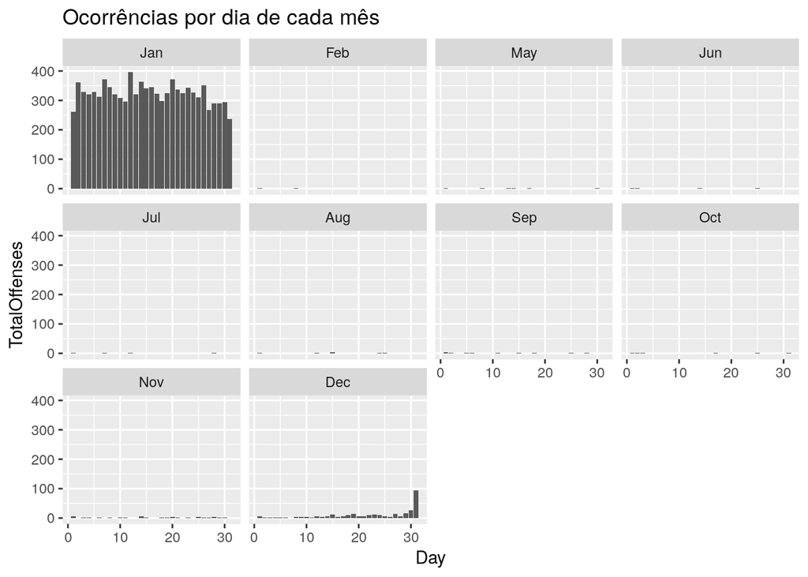

Neste gráfico, é possível perceber em que alturas de cada mês é que ocorrem mais crimes, bem como comparar as diferentes alturas de cada mês entre si. Dada a natureza dos dados disponibilizados, quase todas as ocorrências estão registadas em Janeiro, pelo que se torna difícil tirar conclusões sobre a distribuição de crimes num ano inteiro.

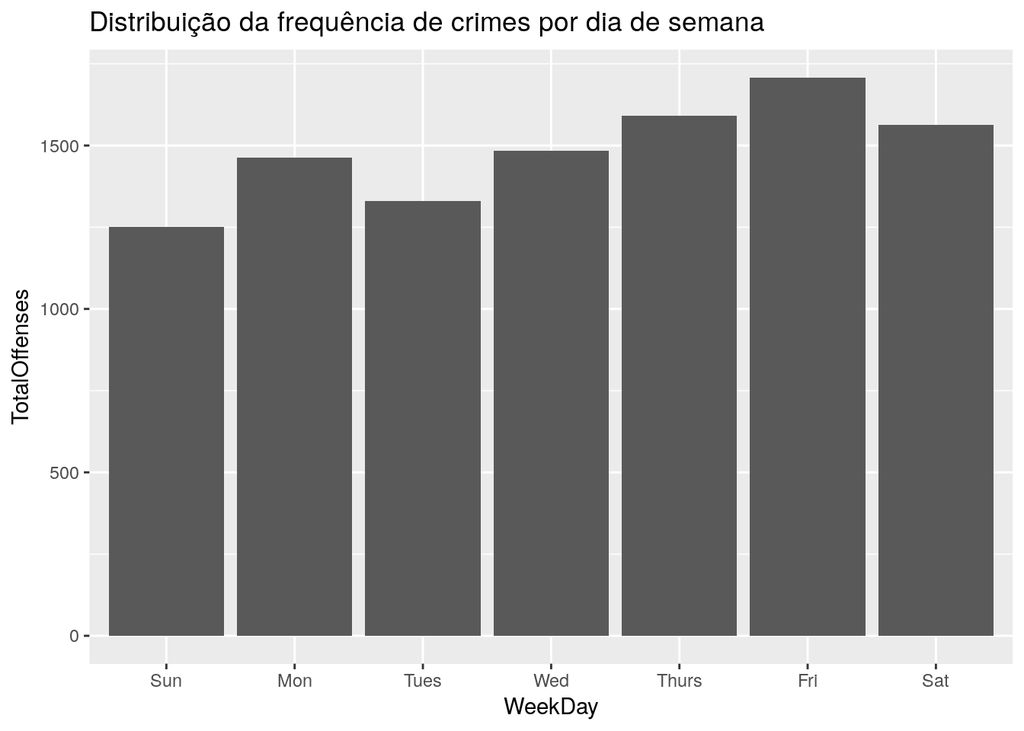

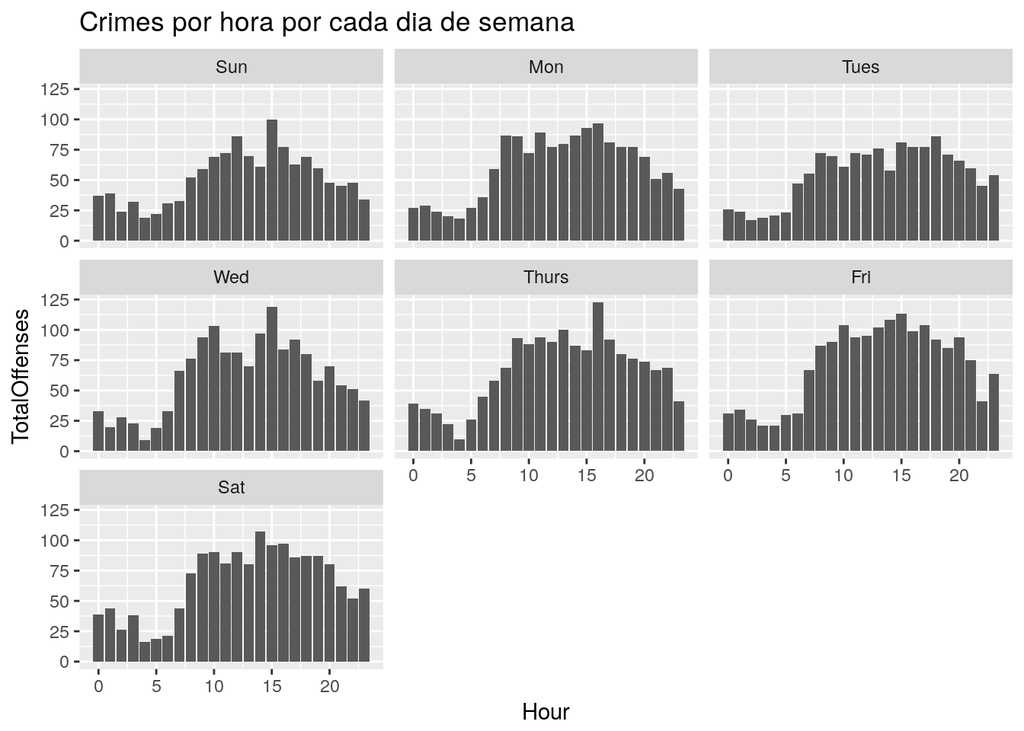

Com a ajuda destes dois gráficos, é possível fazer uma interpretação muito mais detalhada de quando ocorrem mais crimes, já que podemos comparar a quantidade de ocorrências em cada dia de semana e também perceber em que horas de cada dia de semana é que sucedem delitos.

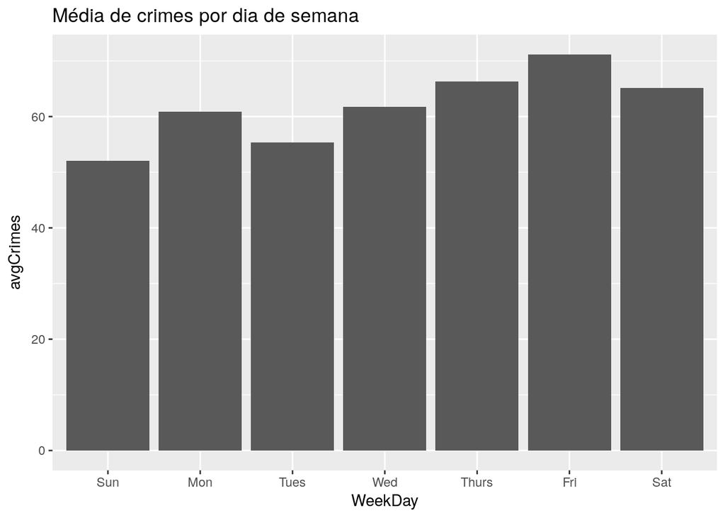

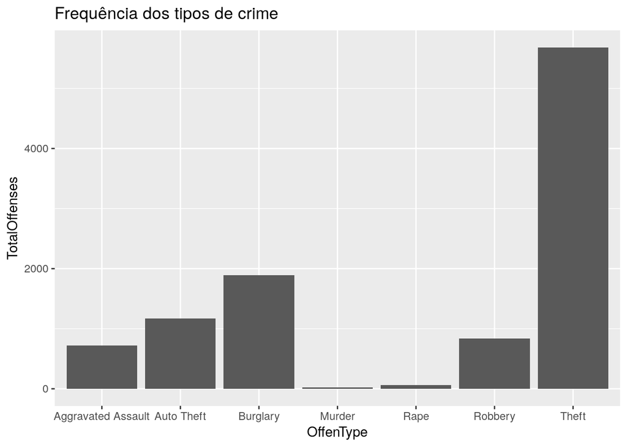

Um gráfico de barras que considera as frequências dos tipos de crime é útil para perceber que tipos de crime ocorrem mais regularmente, o que poderá eventualmente ajudar a decidir quais os procedimentos a tomar na maioria dos casos ou a necessidade de dispôr equipas especiais para certos crimes, por exemplo.

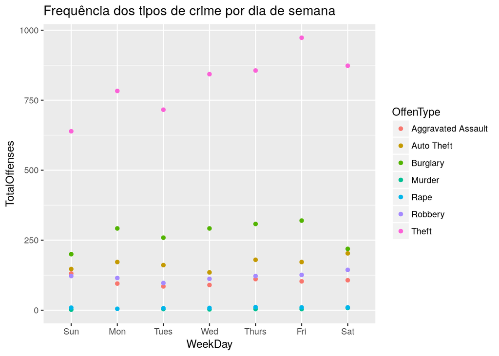

Com a ajuda de um scatterplot, agrupando pelo tipo de crime e distribuindo a frequência de cada tipo de crime por dia de semana, podemos visualizar quais são os crimes mais frequentes em cada momento da semana.

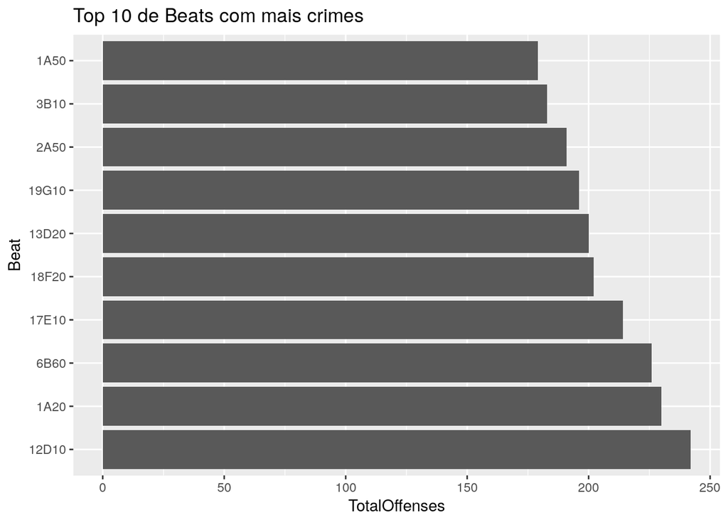

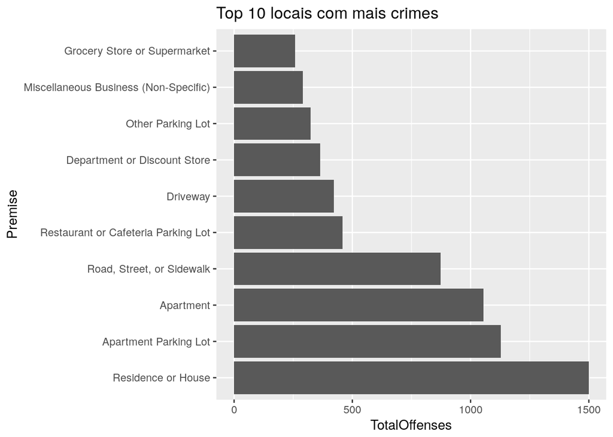

A partir dos dados fornecidos, podemos facilmente perceber quais as regiões (beats) com mais crimes historicamente, bem como os tipos de local mais afectados.

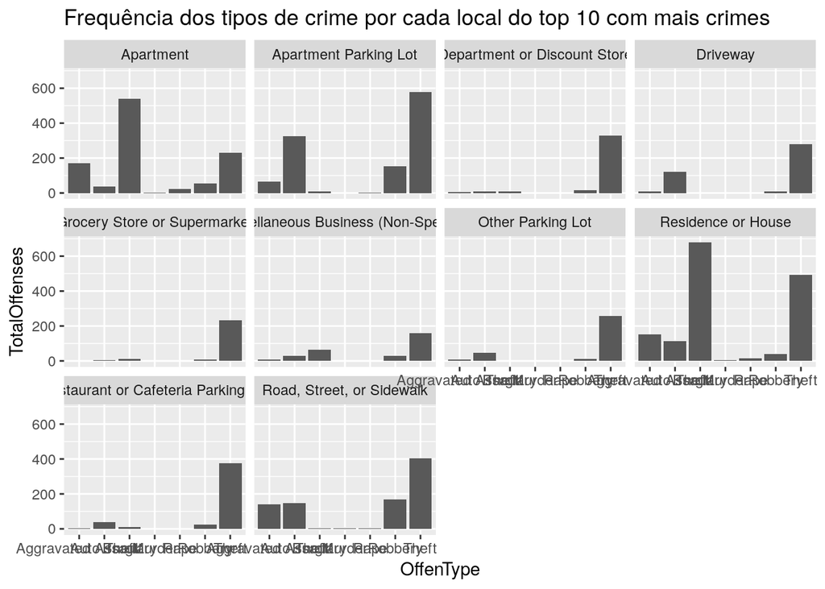

Ao combinar a frequência dos tipos de crime com o top 10 de locais com mais crimes, podemos visualizar quais os crimes mais comuns em cada um dos tipos de local aparentemente mais apetecíveis para os criminosos.

## Construção de um modelo de previsão

A construção de um modelo de previsão consiste, em termos gerais, em criar algum sistema que permita prever observações futuras, perceber de que forma é que as características de uma observação podem influenciar o desfecho de algo ou se existe alguma correlação no que foi observado. Considera-se, portanto, que existe alguma função que, dados os descritores de uma observação (os valores de algumas colunas), permite prever ou tirar alguma conclusão no que concerne ao peso desses descritores na existência dessa observação, ou mesmo prever alguma característica de uma observação (variável-alvo).

No nosso caso, após analisar os dados fornecidos, foi possível identificar certos padrões e fazer alguma interpretação do peso de certas variáveis. Por exemplo, notámos que ocorrem mais crimes no período da tarde ou no final da semana, ou que certos tipos de crimes não são tão comuns. Em função desta análise, optámos por utilizar algumas características para tentar distinguir as ocorrências e dar alguma margem para fazer previsões mais personalizadas (ao poder solicitar uma previsão mais detalhada, fornecendo, por exemplo, o tipo de crime e dia de semana). As variáveis escolhidas como descritores foram:

- Tipo de crime (OffenType)
- Dia de semana (WeekDay)
- Hora (Hour)
- Região (Beat)

No que toca à programação do modelo, optámos por construir um modelo baseado em Decision Tree, uma vez que é um problema de regressão (queremos determinar quantos crimes vão acontecer) e os modelos em árvore podem ser facilmente visualizados para perceber o mecanismo de decisão.

Inicialmente, construímos uma tabela agrupada pelos descritores referidos e com o número de ocorrências registado em cada um desses grupos:

```r
crimes_pred <- summarise(group_by(crimes, OffenType, WeekDay, Hour, Beat), TO=sum(NrOffen))
```

Para testar a nossa hipótese, dividimos os dados em 70% para um conjunto de dados para treino e 30% para um conjunto de dados para teste do modelo. Utilizamos uma seed antes de proceder à divisão para garantir que os valores e modelo referidos no relatório não divergem da nossa explicação.

```r
set.seed(50)
sp <- sample(1:nrow(crimes_pred), as.integer(nrow(crimes_pred) * 0.7))
tr <- crimes_pred[sp, ]
ts <- crimes_pred[-sp, ]
```

Procedemos, então, à construção do modelo, utilizando os dados de treino para preparar a árvore de decisão.

```r
tree <- rpartXse(TO ~ ., tr)
```

A árvore produzida pela função *rpartXse* pode ser vista no esquema seguinte.

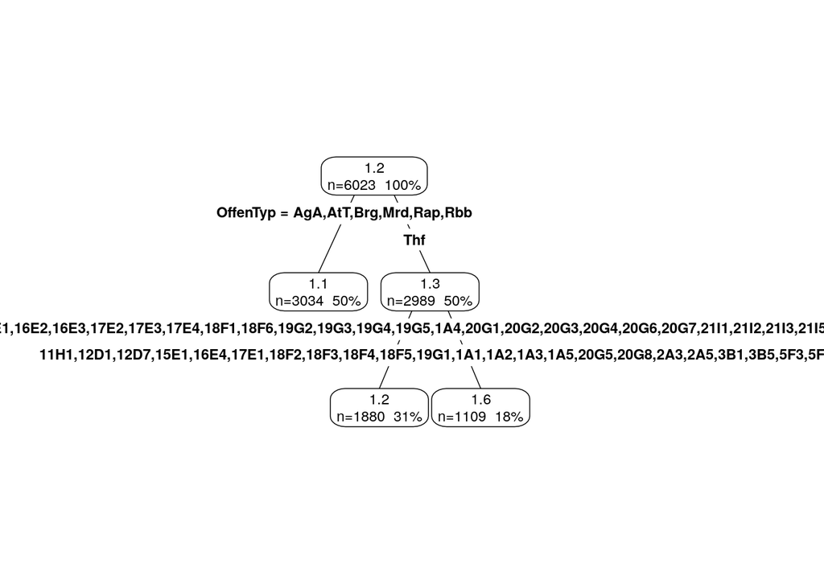

```r
library(rpart.plot)
prp(tree, type=4, extra=101)
```

```r
ps <- predict(tree,ts)
mae <- mean(abs(ps-ts$TO))
```

Para utilizar o modelo numa situação real, podemos criar uma tabela com todas as possibilidades de tipos de crime, dias de semana, horas e beats, prevendo depois o número de ocorrências para cada possibilidade.

```r
library(utils)

# Preparar a tabela com todas as combinacoes de tipo de crime, dia de semana, horas, beats

t <- expand.grid(OffenType=unique(crimes$OffenType), WeekDay=unique(crimes$WeekDay), Hour=unique(crimes$Hour), Beat=unique(crimes$Beat))

# Adicionar coluna para numero de ocorrencias

t["TO"] <- NA

# Efectuar previsao do numero de ocorrencias

preds <- predict(tree, t)

# Juntar a previsao a tabela gerada no inicio

t["TO"] <- preds

# Arredondar os valores para fazerem sentido

t$TO <- round(t$TO)
```

O frame *t* passará a ter todas as combinações de tipos de crime, dias de semana, horas, beats e número previsto de ocorrências. Para responder à questão do enunciado, onde se pede para prever o número de ocorrências num determinado beat para algum período de um dia, podemos agrupar os resultados obtidos e teremos a resposta.

```r
t <- mutate(t, Period = get_period(Hour))
group_t <- summarise(group_by(t, Beat, Period, WeekDay), TotalOccurrences=sum(TO))
print(group_t, n=nrow(group_t))
```

```
## Source: local data frame [2,415 x 4]
## Groups: Beat, Period [?]
##
##        Beat    Period WeekDay TotalOccurrences
##      <fctr>     <chr>   <ord>            <dbl>
## 1     10H10 afternoon     Sun               49
## 2     10H10 afternoon     Mon               49
## 3     10H10 afternoon    Tues               49
## 4     10H10 afternoon     Wed               49
## 5     10H10 afternoon   Thurs               49
## 6     10H10 afternoon     Fri               49
## 7     10H10 afternoon     Sat               49
## 8     10H10   morning     Sun               28
## 9     10H10   morning     Mon               28
## 10    10H10   morning    Tues               28
```

[output cut: 2405 more lines]

Em todo o caso, o modelo proposto tem liberdade para fazer estas previsões só para um certo tipo de crimes, um certo período, um certo beat ou um certo dia de semana, ou algum tipo de combinação dessas características, ao preencher a tabela adequadamente.